# Imputation for AR Time Series

Junyan Liu and Daniel P. Palomar Hong Kong University of Science and Technology (HKUST)

2019-03-28

> This vignette illustrates the usage of the package `imputeFin` for imputation of missing Values in incomplete AR time series.

# Installation

The package can currently be installed from [GitHub](https://github.com/dppalomar/imputeFin):

```r
# install.packages("devtools")
devtools::install_github("dppalomar/imputeFin")
# Getting help
library(imputeFin)
help(package = "imputeFin")
package?imputeFin
?imputeFin
```

# Usage of the package

## Estimation and imputation for incomplete AR(1) time series

We start by loading the package:

```r
library(imputeFin)
```

We download the adjusted price of S&P 500 index from 2012-01-01 to 2015-07-08, and compute the log prices. Some log prices are deleted to generate missing values.

```r
library(xts)
library(quantmod)
y_orig <- log(Ad(getSymbols("^GSPC", from = "2012-01-01", to = "2015-07-08", auto.assign = FALSE)))
n <- nrow(y_orig)
miss_pct <- 0.2 # the percentage of missing values
n_miss <- floor(miss_pct*n)
index_miss <- round(n/2) + 1:n_miss
y <- y_orig
y[index_miss] <- NA
```

Then we use the function `estimateAR1t()` to estimate the parameters of Student’s t AR(1) model from this incomplete time series.

```r
estimation_result <- estimateAR1t(y，zero_mean = FALSE)
estimation_result$phi0
```

```
#> [1] 0.01196507
```

```r
estimation_result$phi1
```

```
#> [1] 0.9984751
```

```r
estimation_result$sigma2
```

```
#> [1] 3.659148e-05
```

```r
estimation_result$nu
```

```
#> [1] 4.940846
```

```r
imputation_result <- imputeAR1t(y, n_sample = 3，zero_mean = FALSE)
```

Next, we use the function `imputeAR1t()` to impute the missing values in the incomplete time series.

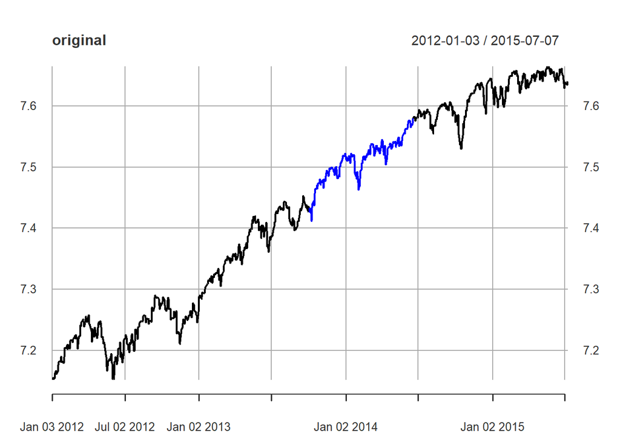

```r
# we generate n_sample = 2 imputed time series
imputation_result <- imputeAR1t(y, n_sample = 2，zero_mean = FALSE)
y_imputed <- imputation_result$y_imputed
index_miss_bis <- (min(index_miss)-1):(max(index_miss)+1)
{ plot(y, main = "original")
  lines(y_orig[index_miss_bis, 1], col="blue", lwd=2) }  # plot the original time series
```

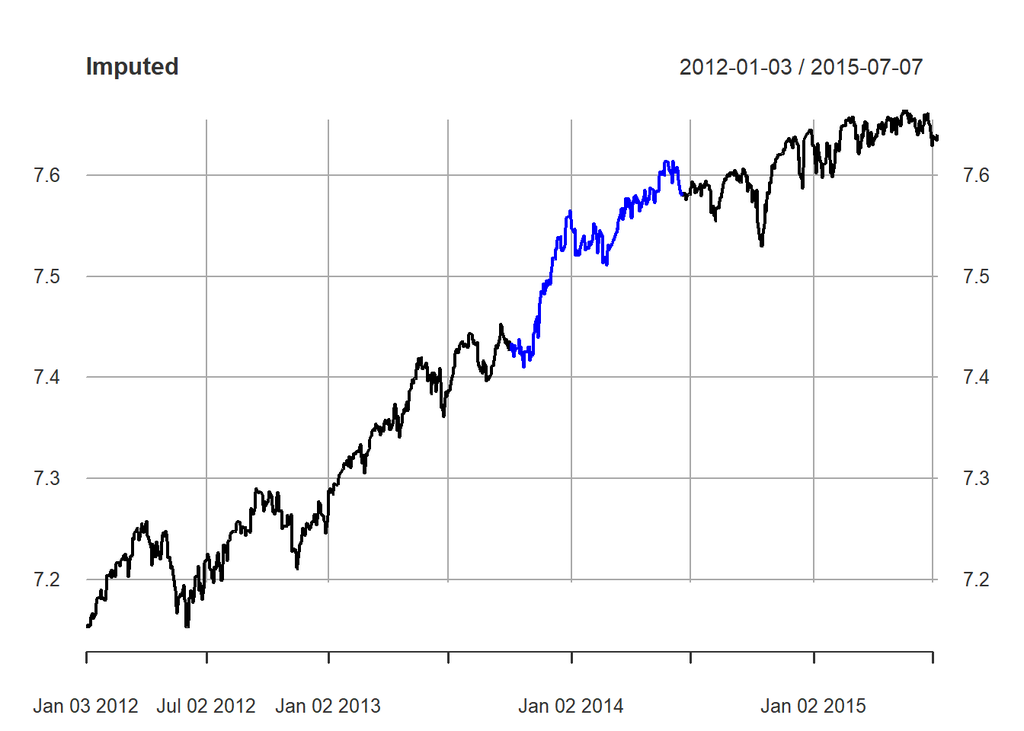

```r
{ plot(y, main="Imputed")
  lines(y_imputed[index_miss_bis, 1], col="blue", lwd=2) }#plot the first imputed time series
```

```r
# if we have already known the parameters, then we can use this information when doing the imputation.
param  <- list("phi0" = estimation_result$phi0,
               "phi1" = estimation_result$phi1,
               "sigma2" = estimation_result$sigma2,
               "nu" = estimation_result$nu)
imputation_result <- imputeAR1Gaussian(y, n_sample = 2, param，zero_mean = FALSE)
```

The functions `estimateAR1t()` and `imputeAR1t()` can also deal with multivariate incomplete time series. They will do estimatation and imputation for each univariate time series seperately.

```r
stocks = lapply(c("^GSPC","^HSI"), function(sym) {
  log(Ad(getSymbols(sym, from = "2018-01-01", to = "2019-01-01", auto.assign = FALSE)))
})
Y_orig = do.call(merge, stocks)
n <- nrow(Y_orig)
miss_pct1 <- 0.1 # the percentage of missing values
miss_pct2 <- 0.2
index_miss1 <- sort(sample(2:(n - 1), n * miss_pct1))
index_miss2 <- sort(sample(2:(n - 1), n * miss_pct2))
Y <- Y_orig
Y[index_miss1, 1] <- NA
Y[index_miss2, 2] <- NA

estimation_result <- estimateAR1t(Y, zero_mean = FALSE)
imputation_result <- imputeAR1t(Y, n_sample = 2, zero_mean = FALSE)
```

The functions `estimateAR1Gaussian()` and `imputeAR1Gaussian()` can be used in a similar way. Instead of the Student’s t AR(1) model, they fit the Gaussian AR(1) model to time series.

```r
estimation_result_g <- estimateAR1Gaussian(y,  zero_mean = FALSE)
estimation_result_g$phi0
```

```
#> [1] 0.01479403
```

```r
estimation_result_g$phi1
```

```
#> [1] 0.9980842
```

```r
estimation_result_g$sigma2
```

```
#> [1] 5.712408e-05
```

```r
imputation_result_g <- imputeAR1Gaussian(y, n_sample = 2,  zero_mean = FALSE)
```

# Comparison with other packages

We compare with the existing package `imputeTS`. We plot the imputed time series obtained by functions in package `imputeTS` and our function `imputeAR1t()`，respectively.

```r
# impute using package imputeTS
library("imputeTS")
```

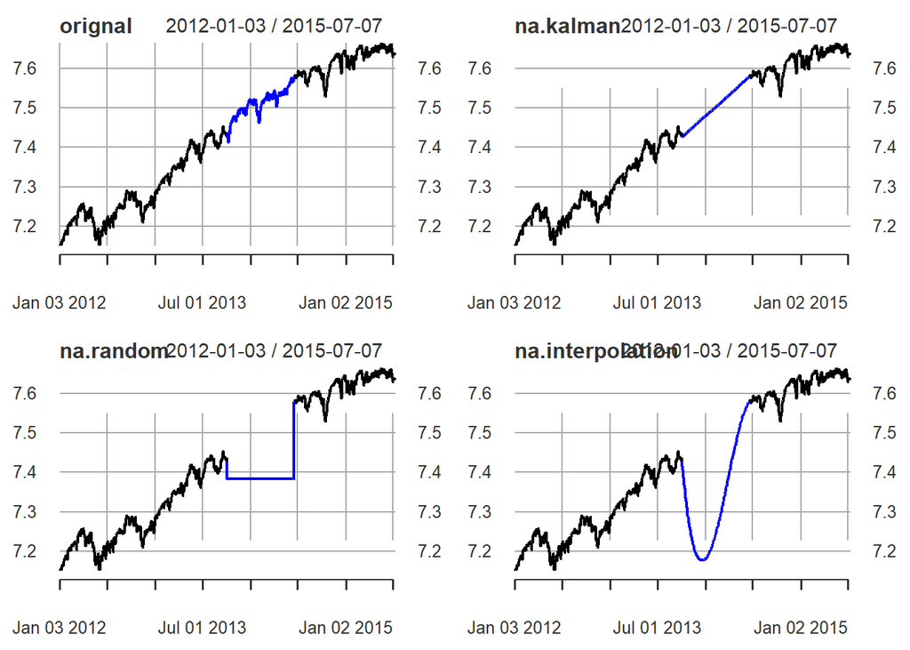

```r
y_imputed_km = na.kalman(y)
y_imputed_random = na.random(y)
y_imputed_linear = na.interpolation(y, "spline")
par(mfrow=c(2,2))
#plot 1
{ plot(y, main="orignal")
  lines(y_orig[index_miss_bis], col="blue", lwd=2) }
#plot 2
{ plot(y, main="na.kalman")
  lines(y_imputed_km[index_miss_bis], col="blue", lwd=2) }
#plot 3
{ plot(y, main="na.random")
  lines(y_imputed_random [index_miss_bis], col="blue", lwd=2) }
#plot 4
{ plot(y, main="na.interpolation")
  lines(y_imputed_linear[index_miss_bis], col="blue", lwd=2) }
```

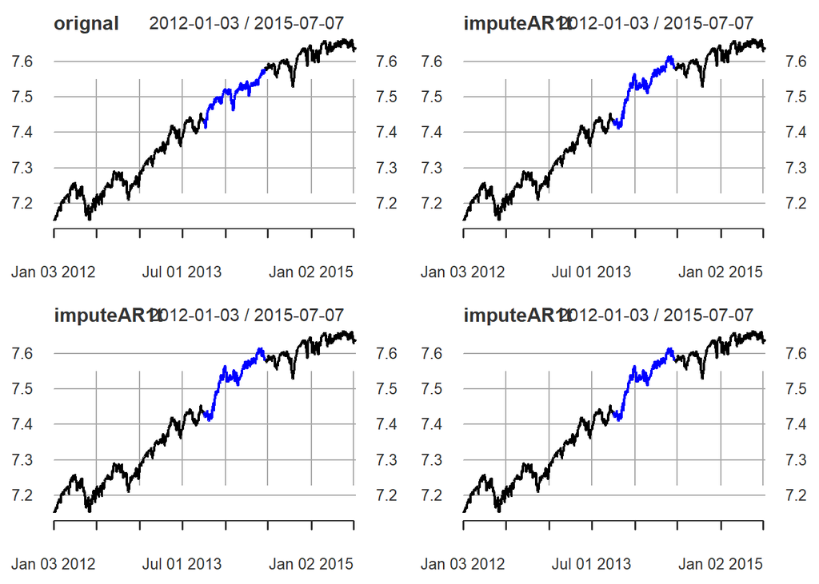

```r
par(mfrow=c(2,2))
#plot 1
{ plot(y, main="orignal")
  lines(y_orig[index_miss_bis], col="blue", lwd=2) }
#plot 2
{ plot(y, main="imputeAR1t")
  lines(y_imputed[index_miss_bis, 1], col="blue", lwd=2) }
#plot 3
{ plot(y, main="imputeAR1t")
  lines(y_imputed[index_miss_bis, 1], col="blue", lwd=2) }
#plot 4
{ plot(y, main="imputeAR1t")
  lines(y_imputed[index_miss_bis, 1], col="blue", lwd=2) }
```